# Mapping Phenomena Relevant to Adolescent Emotion Dysregulation: A Text-mining Systematic Review

<sup>1</sup>: Utrecht University, dept. Methodology & Statistics  
Funded by NWO Veni grant VI.Veni.191G.090

## Emotion regulation in adolescence

Developmentally sensitive period for emotion regulation (Zimmermann and Iwanski 2014)

As many as one in five develop psychopathology (Lee et al. 2014)

Potentially lifelong implications for mental health and well-being

Need to know what phenomena are associated with adolescents’ emotion regulation

## Knowledge gap

Substantial empirical research has addressed this topic, but:

- Different (sub)disciplines have approached the topic in disparate ways (Riediger and Klipker 2014)
- No consistent terminology (Bariola, Gullone, and Hughes 2011)
- No conceptual frameworks (Stifter and Augustine 2019)
- No overarching theoretical framework (Buss, Cole, and Zhou 2019)

There is a need for the integration of knowledge across research areas and consolidation of empirical research into overarching theory.

## Moving forward

According to *Theory Construction Methods*, first step toward a unifying framework is identifying relevant phenomena (Borsboom et al. 2020)

- Phenomena: stable and general features of the world

Few tools exist for identifying relevant phenomena (aside from expert opinion)

*This paper argues that systematic reviews are a suitable and relatively more objective method for phenomena detection.*

## Why text mining?

Narrative reviews are limited by small samples, confirmation bias, and emphasis on positive results (Littell 2008)

*Text mining systematic review (TMSR):*

- Covers arbitrarily greater corpora
- Derives insights through a transparent, objective, and reproducible process
- Assumes that term frequency indicates relevance of phenomena
- Assumes that co-occurrence frequency indicates putative associations
  - These metrics can be jointly visualized as a network graph
  - Thus “mapping” phenomena relevant to adolescent emotion regulation
  - Co-occurrence graph ~= rudimentary nomological network

## Relevant theory

- Bioecological model (Bronfenbrenner and Morris 2007)
- Transactional model (Sameroff 2010)
- Hall’s notion of “storm and stress”
- Theory of normative emotional development (Sroufe 1995)
- Tripartite model (Morris et al. 2007)
- Internalization model of emotional development (Holodynski and Friedlmeier 2006)
- Polyvagal theory (Porges 1995).
- Model of social-affective engagement and goal flexibility (Crone and Dahl 2012)
- Process model of emotion regulation (Gross 2013)
- Social Information Processing Theory (Lemerise and Arsenio 2000)

## Baseline network

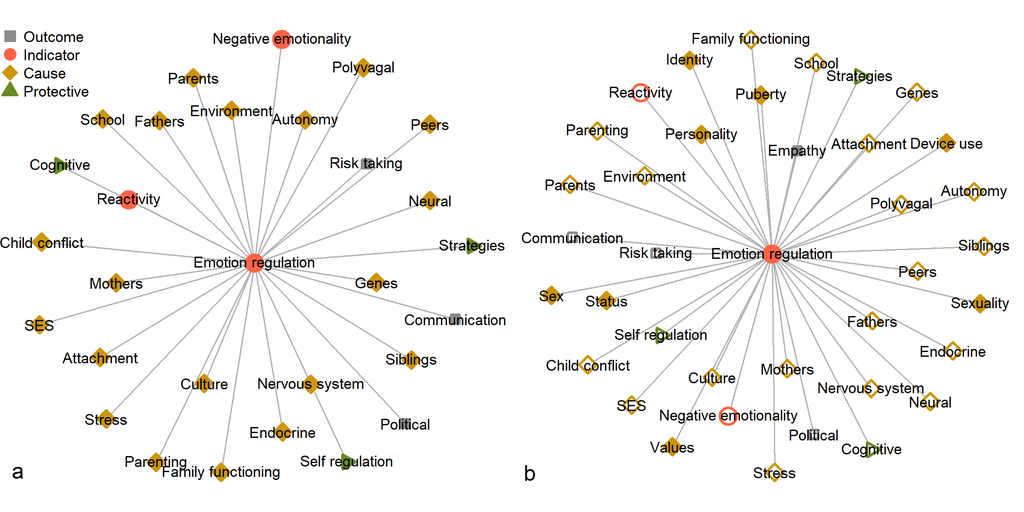

Phenomena relevant to adolescents’ emotion regulation according to theory (a) and narrative reviews (b; transparent nodes indicate constructs also present in the theory).

Phenomena relevant to adolescents’ emotion regulation according to theory (a) and narrative reviews (b; transparent nodes indicate constructs also present in the theory).

## Limitations of relevant theory

- Few explicitly address adolescence
- Few have comprehensively addressed important predictors of development in this life stage
- None directly guide contemporary research
- Theories vary widely in scope: Some are broad and non-specific; others describe a specific phenomenon in detail, but lack a broader perspective.
  - Broad theories can frame any research, specific theories generate hypotheses.
  - It would be beneficial to bridge these levels of analysis.

## Methods

## Open science

All code and data available at github.com/cjvanlissa/veni_sysrev

Workflow for Open Reproducible Code in Science (WORCS) used to make analyses reproducible (Van Lissa et al. 2020)

## Search strategy

Based on procedures by Staaks (Staaks 2019)

Web of Science

Reference set of 29 articles

Search string constructed to retrieve this set (synonyms of emotion regulation and adolescence)

6653 results including 25 of the reference set

## Screening

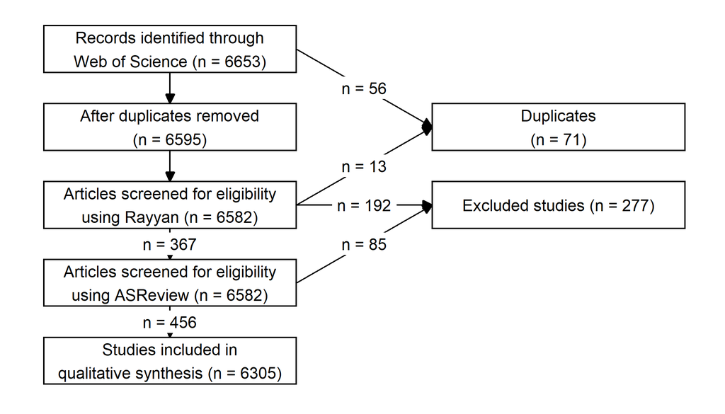

Addresses **emotion regulation** in population overlapping with age range [10-24]

## Screening contd.

Preliminary screening was conducted in Rayyan.

After 367 papers, screening continued in the free open source program ASReview (Van de Schoot et al. 2020)

Algorithm: “naive Bayes”

Reverse coding: Excluded articles coded as hits

Screening continued until among the most recently screened 100 papers only 6 were excluded

## Screening contd.

Experienced challenges:

- First version required NVidia CUDA
- Difficult to set up Python environment
- Workaround for corpus with mostly relevant publications
- Would be better to have automatic cutoff

## Analysis 1: Author keywords

## Method

84 remaining terms, occurring in 4827 documents

## Mapping the literature

- Term co-occurrence matrix, 2498 co-occurrence relationships
- Small coefficients again pruned using \(97.5^{th}\) percentile of negative binomial (25+ documents)

106 co-occurrence relationships remained

Terms categorized as cause, outcome, protective factor, or indicator of emotion regulation

## Analysis 2: Abstract text mining

## Method

Nouns and adjectives help derive more interpretable text mining models (Martin and Johnson 2015)

Nouns capture terms like “emotion”; adjectives capture the “mental” in “mental health”

Used “part-of-speech tagging” (POS-tagging) to identify words’ grammatical functions

Stemmed terms to their root

Identified trigrams using `textrank` (Wijffels 2019)

- E.g., “emotion regulation” is already a bigram

Merged trigrams with original data

## Method contd.

- 5097 documents with 11448 unique words
- Pruned \(97.5^{th}\) percentile (6+ documents)
- 850 co-occurrence relationships
- Pruned \(97.5^{th}\) percentile (10+ documents)

43 remaining co-occurrence relationships

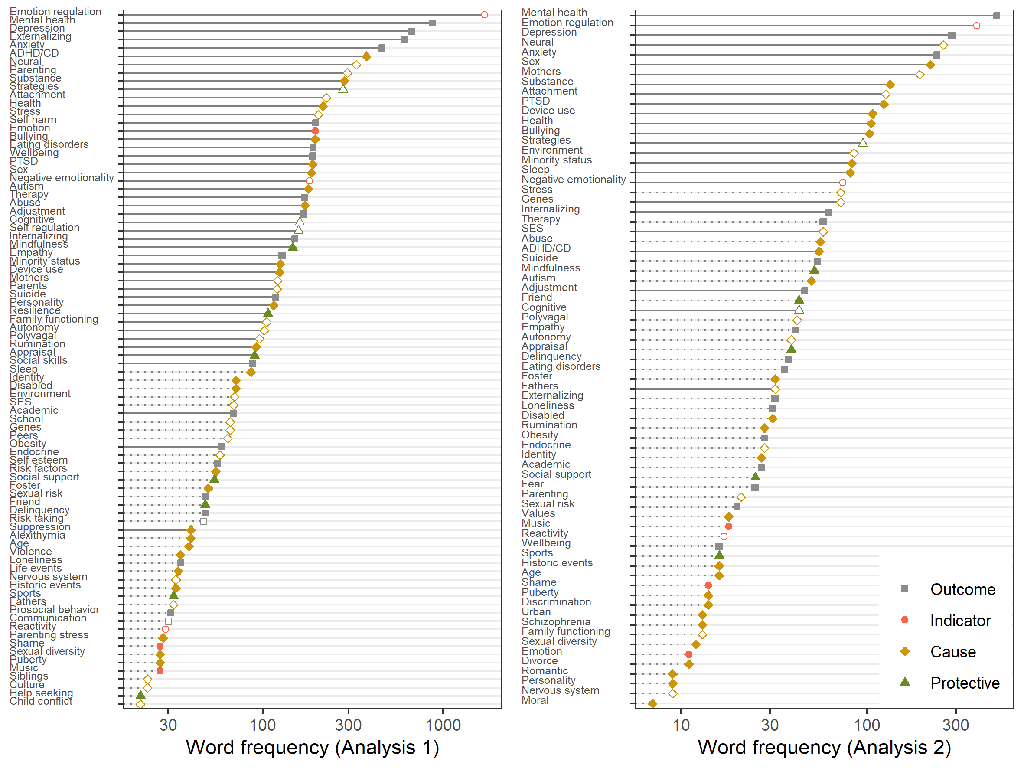

## Co-occurrence graph

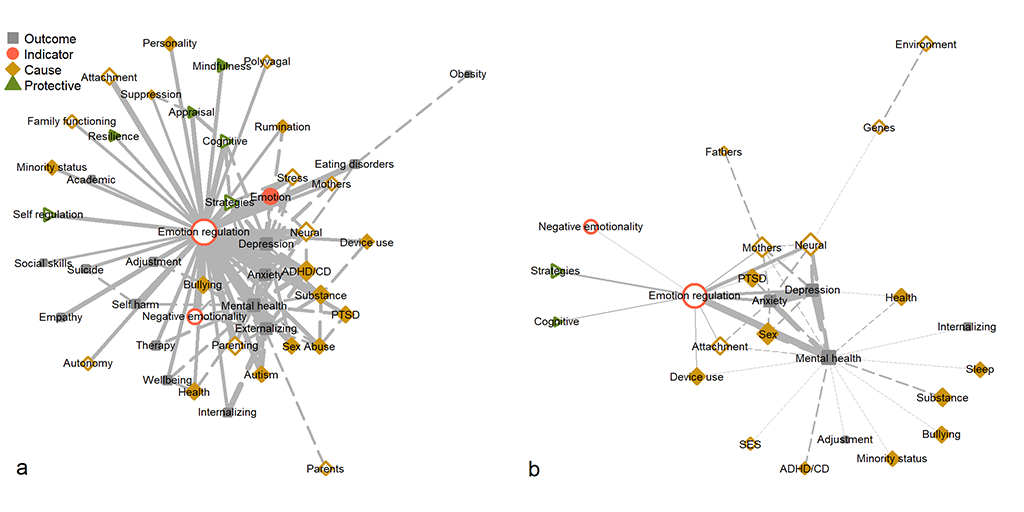

Author keywords (a) and abstracts (b)

## Results: Important phenomena

- Emotion regulation and related mental health outcomes among top terms
- Theoretically important themes: *neural*, *parenting*, and *stress*
- Also several under-theorized concepts: *ADHD/CD*, *substance* use, *minority status*
- Substantial correspondence between keywords and abstracts
  - 75% of frequent terms from keywords also present in abstracts
  - 89% of the frequent terms from abstracts present in keywords
- *sex* was more frequent in the Abstracts: sex differences are regularly reported in Abstracts even if they are not mentioned in the keywords
- *parenting* (keywords) was displaced by *mothers* (Abstracts): Parenting is often operationalized as mothering

## Results: Co-occurrence

Keywords:

- Emotion regulation is a central construct to which other constructs are directly linked
- Graph was sparse, with few interconnections between terms (fragmented literature?)

## Discussion

- Both analyses reflected some phenomena from theoretical literature
  - Particularly related to neurodevelopment and socialization
- Mental health-related outcomes feature prominently
  - Emotion regulation implicated in mental health problems (Lee et al. 2014),
  - This underlines the importance of research in this area

## Undertheorized themes

- Developmental disorders
  - E.g., ADHD/CD and autism
- Physical health (sic)
  - sleep, sports, and disability status
- External stressors
  - bullying, stress, PTSD, abuse, violence, life events, historic events (e.g., earthquakes, war), parenting stress, and divorce.
- Structural disadvantage
  - minority status, discrimination, disability status, socio-economic status, adoption status, and sexual diversity
  - Developmental disorders also relevant in this context, as neuroatypical individuals tend to experience social exclusion (Cappadocia, Weiss, and Pepler 2012)

## Undertheorized themes contd.

- Addictive behavior
  - substance use and device use
- Identity and moral development
  - values and personality.
- Sexual development
  - (biological) sex, puberty, sexual diversity, and romantic relationships

Text mining systematic reviews can thus identify undertheorized themes

## Structural findings

Central axis of emotion regulation and mental health outcomes suggests that these phenomena are closely linked

Sparse networks (fragmented literature)

- Most phenomena directly linked with emotion regulation/mental health
- Absence of terms suggests that they are not well-integrated in the literature
- Sparser network for Abstractslikely reflects greater noise

Substantial correspondence between both networks

- Supports validity of the findings, suggests that automatic keyword extraction identifies relevant constructs

## Implications

Results reflected familiar phenomena: Suggests validity of the method

Results also revealed under-theorized phenomena: TMSR may complement theory and narrative reviews

Implications for future empirical research:

- Researchers typically rely on theory
- Under-theorized phenomena may be overlooked
- This study offers guidance regarding relevant phenomena to consider as confounders or contributing causes
- Unembedded terms indicate potential knowledge gaps; promising areas of future research

## Theoretical implications

- Sparse graphs indicate fragmented literature
- Important to generate an overarching theory of adolescent emotion regulation
- First step in theory construction methodology is to identify relevant phenomena (Borsboom et al. 2020)
- Present study thus serves as starting point for theory development

## Stengths

- This study was more comprehensive than previous narrative reviews (cf. Bariola, Gullone, and Hughes 2011; Coe-Odess, Narr, and Allen 2019)
  - Used systematic search and included much larger corpus
- TMSR can include corpora of arbitrary size, and derive insights by transparant and reproducible procedures

## Limitations

- These text mining techniques do not extract *meaning* from the literature
- Analyses limited to keywords and abstracts
  - Many full text articles are behind paywalls
  - No standardized Application Programming Interface (API)
- Comprehensive access to scientific publications is essential to all meta-scientific research
- Recommend open access publishing and the development of a unified API for article retrieval
- Subjective decisions were made throughout the analysis process
  - creative license is inherent to inductive studies (Wagenmakers, Dutilh, and Sarafoglou 2018)
  - There are infinite possible ways to conduct exploratory analyses

## Conclusion

Text mining systematic reviews can identify theoretically relevant phenomena, and map potential associations

- This illustrates validity of the method

Results also revealed undertheorized themes

- E.g., developmental disorders, physical health, external stressors, structural disadvantage, substance use, identity, moral, and sexual development

Text mining systematic reviews thus complement theory and narrative reviews

Future theoretical work should integrate undertheorized themes into an overarching framework

Empirical research might consider them as promising areas for future research, or potential confounders and contributing causes

## References

Bariola, Emily, Eleonora Gullone, and Elizabeth K. Hughes. 2011. “Child and Adolescent Emotion Regulation: The Role of Parental Emotion Regulation and Expression.” *Clinical Child and Family Psychology Review* 14 (2): 198. https://doi.org/10.1007/s10567-011-0092-5.

Borsboom, Denny, Jonas Dalege, Rogier A Kievit, and Brian D Haig. 2020. “Theory Construction Methodology: A Practical Framework for Building Theories in Psychology.” PsyArxiv. February 29, 2020. https://doi.org/10.31234/osf.io/w5tp8.

Bronfenbrenner, Urie, and Pamela A. Morris. 2007. “The Bioecological Model of Human Development.” In *Handbook of Child Psychology*. John Wiley & Sons, Inc. https://doi.org/10.1002/9780470147658.chpsy0114.

Buss, Kristin A., Pamela M. Cole, and Anna M. Zhou. 2019. “Theories of Emotional Development: Where Have We Been and Where Are We Now?” In *Handbook of Emotional Development*, edited by Vanessa LoBue, Koraly Pérez-Edgar, and Kristin A. Buss, 7–25. Cham: Springer International Publishing. https://doi.org/10.1007/978-3-030-17332-6_2.

Cappadocia, M. Catherine, Jonathan A. Weiss, and Debra Pepler. 2012. “Bullying Experiences Among Children and Youth with Autism Spectrum Disorders.” *Journal of Autism and Developmental Disorders* 42 (2): 266–77. https://doi.org/10.1007/s10803-011-1241-x.

Coe-Odess, Sarah J., Rachel K. Narr, and Joseph P. Allen. 2019. “Emergent Emotions in Adolescence.” In *Handbook of Emotional Development*, edited by Vanessa LoBue, Koraly Pérez-Edgar, and Kristin A. Buss, 595–625. Cham: Springer International Publishing. https://doi.org/10.1007/978-3-030-17332-6_23.

Crone, Eveline A., and Ronald E. Dahl. 2012. “Understanding Adolescence as a Period of Social–Affective Engagement and Goal Flexibility.” *Nature Reviews Neuroscience* 13 (9): 636–50. https://doi.org/10.1038/nrn3313.

Gross, James J. 2013. *Handbook of Emotion Regulation*. Book, Whole. Guilford publications.

Holodynski, Manfred, and Wolfgang Friedlmeier. 2006. *Development of Emotions and Emotion Regulation*. Springer Science & Business Media. http://books.google.com?id=OvJHncpZEQUC.

Lee, Francis S., Hakon Heimer, Jay N. Giedd, Edward S. Lein, Nenad Šestan, Daniel R. Weinberger, and B. J. Casey. 2014. “Adolescent Mental Health— Opportunity and Obligation.” *Science* 346 (6209): 547–49. https://doi.org/10.1126/science.1260497.

Lemerise, Elizabeth A., and William F. Arsenio. 2000. “An Integrated Model of Emotion Processes and Cognition in Social Information Processing.” *Child Development* 71 (1): 107–18. https://doi.org/10.1111/1467-8624.00124.

Littell, Julia H. 2008. “Evidence-Based or Biased? The Quality of Published Reviews of Evidence-Based Practices.” *Children and Youth Services Review* 30 (11): 1299–1317. https://doi.org/10.1016/j.childyouth.2008.04.001.

Martin, Fiona, and Mark Johnson. 2015. “More Efﬁcient Topic Modelling Through a Noun Only Approach.” In *Proceedings of Australasian Language Technology Association Workshop*, 111–15.

Morris, Amanda Sheffield, Jennifer S. Silk, Laurence Steinberg, Sonya S. Myers, and Lara Rachel Robinson. 2007. “The Role of the Family Context in the Development of Emotion Regulation.” *Social Development* 16 (2): 361–88. https://doi.org/10.1111/j.1467-9507.2007.00389.x.

Porges, Stephen W. 1995. “Orienting in a Defensive World: Mammalian Modifications of Our Evolutionary Heritage. A Polyvagal Theory.” *Psychophysiology* 32 (4): 301–18. https://doi.org/10.1111/j.1469-8986.1995.tb01213.x.

Riediger, Michaela, and Kathrin Klipker. 2014. “Emotion Regulation in Adolescence.” In *Handbook of Emotion Regulation*, 187–202. Guilford Press.

Sameroff, Arnold. 2010. “A Unified Theory of Development: A Dialectic Integration of Nature and Nurture.” *Child Development* 81 (1): 6–22. https://doi.org/10.1111/j.1467-8624.2009.01378.x.

Sroufe, L. Alan. 1995. *Emotional Development: The Organization of Emotional Life in the Early Years*. Cambridge Studies in Social and Emotional Development. Cambridge: Cambridge University Press. https://doi.org/10.1017/CBO9780511527661.

Staaks, Janneke. 2019. “Systematic Review Search Support.” 2019. https://doi.org/10.17605/OSF.IO/49T8X.

Stifter, Cynthia, and Mairin Augustine. 2019. “Emotion Regulation.” In *Handbook of Emotional Development*, edited by Vanessa LoBue, Koraly Pérez-Edgar, and Kristin A. Buss, 405–30. Cham: Springer International Publishing. https://doi.org/10.1007/978-3-030-17332-6_16.

Van de Schoot, Rens, Jonathan De Bruin, Raoul Schram, Parisa Zahedi, Jan De Boer, Felix Weijdema, Bianca Kramer, et al. 2020. *ASReview: Active Learning for Systematic Reviews* (version v0.9.5). Zenodo. https://doi.org/10.5281/zenodo.3828293.

Van Lissa, Caspar J., Andreas M. Brandmaier, Loek Brinkman, Anna-Lena Lamprecht, Aaron Peikert, Marijn E. Struiksma, and Barbara Vreede. 2020. “ WORCS: A Workflow for Open Reproducible Code in Science,” May. https://doi.org/10.17605/OSF.IO/ZCVBS.

Wagenmakers, Eric-Jan, Gilles Dutilh, and Alexandra Sarafoglou. 2018. “The Creativity- Verification Cycle in Psychological Science: New Methods to Combat Old Idols.” *Perspectives on Psychological Science* 13 (4): 418–27. https://doi.org/10.1177/1745691618771357.

Wijffels, Jan. 2019. *Textrank: Summarize Text by Ranking Sentences and Finding Keywords*. https://CRAN.R-project.org/package=textrank.

Zimmermann, Peter, and Alexandra Iwanski. 2014. “Emotion Regulation from Early Adolescence to Emerging Adulthood and Middle Adulthood: Age Differences, Gender Differences, and Emotion-Specific Developmental Variations.” *International Journal of Behavioral Development* 38 (2): 182–94.